# Re-selling MC Goods (190821)

Matthias Fuchs

8/21/2019

# Data description

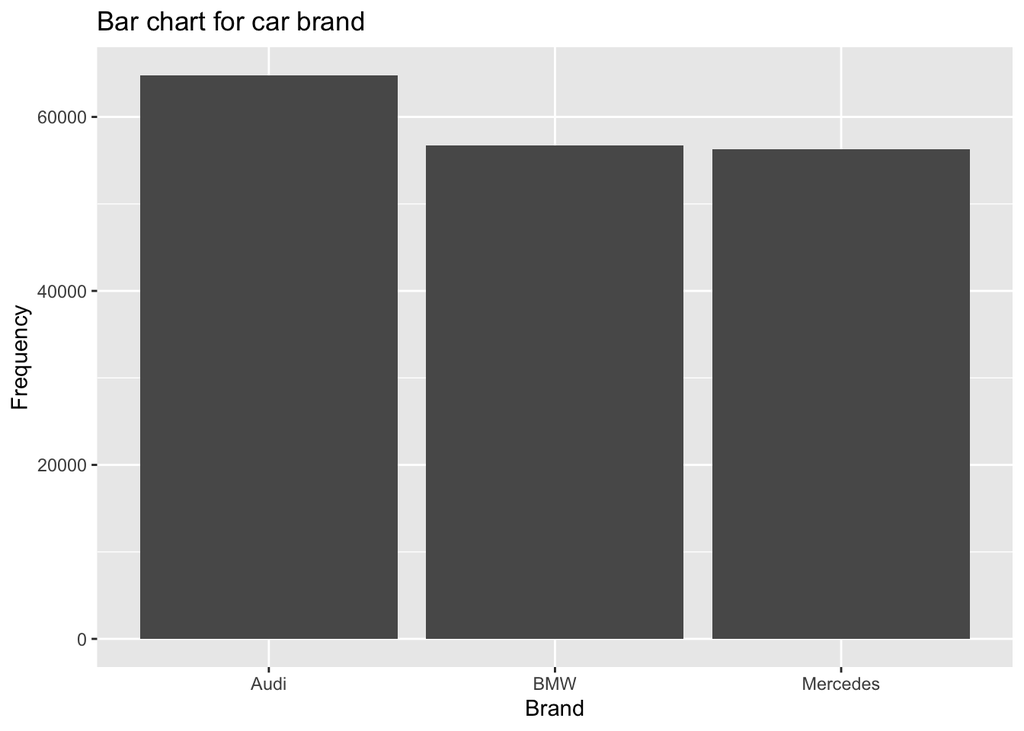

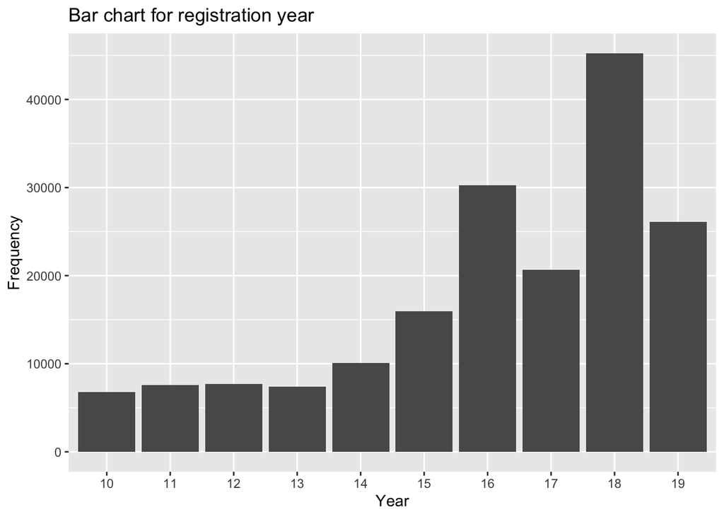

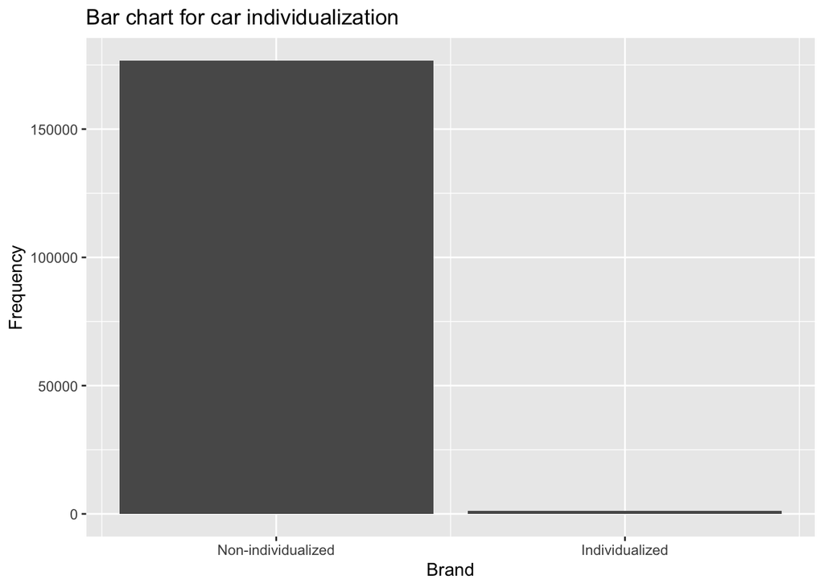

[output not shown]

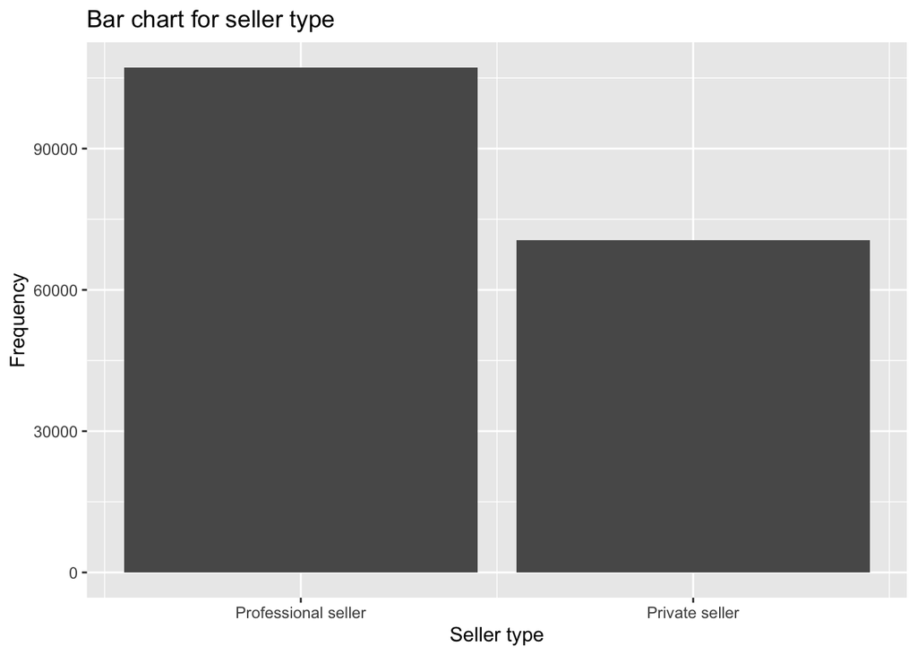

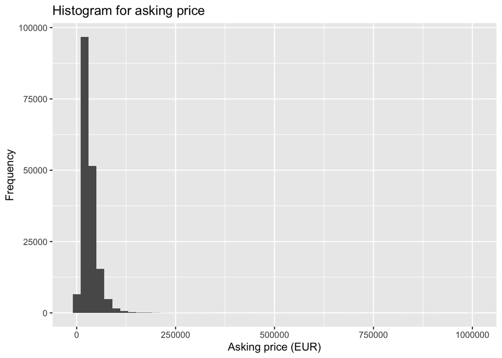

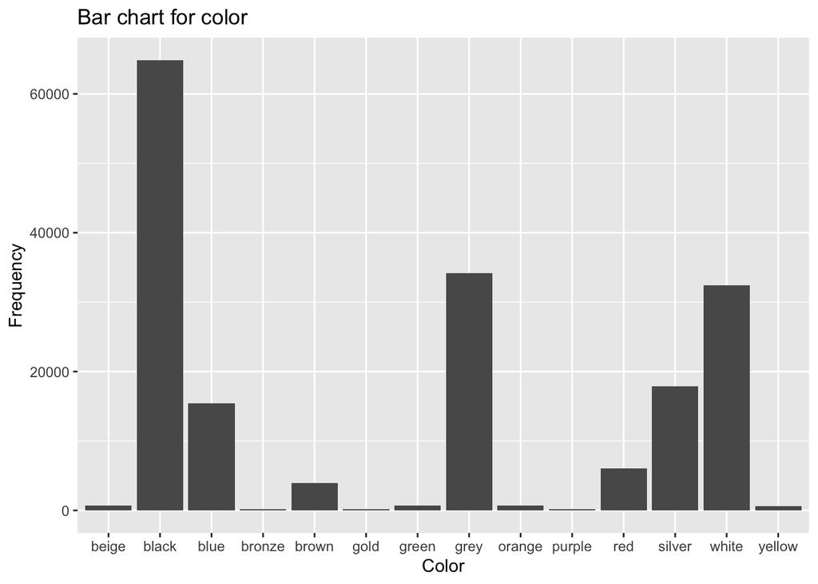

# Color and Asking Price

## Looking at overall color popularity

As can be seen, the overal color popularity does not significantly influence the asking price. This is the case, because there are 2 colors (purple and beige), which are extremely unpopular, but highly valuable.

*Dependent variable:*

Price

colpop

-43.767

(54.027)

privateseller

456.000***

(118.766)

sport

1,688.177***

(67.366)

individual

-4,126.554***

(378.336)

Power

96.302***

(1.190)

sqrt(Mileage)

-35.489***

(0.499)

sqrt(ageindays)

-496.664***

(4.238)

TransmissionHalbautomatik

-1,332.335

(1,728.518)

TransmissionSchaltgetriebe

-489.551***

(83.072)

hud

1,793.928***

(120.197)

acc

518.263***

(151.950)

glasdach

303.703

(164.422)

laser

5,508.547***

(481.546)

led

-1,367.256***

(75.907)

leather

28.252

(111.185)

navi

-1,742.764***

(64.371)

standheizung

254.634

(257.864)

brandBMW

-3,952.845

(7,023.072)

brandMercedes

10,264.460

(6,792.856)

Constant

45,960.220***

(6,251.237)

Observations

171,875

Log Likelihood

-1,858,381.000

Akaike Inf. Crit.

3,716,811.000

Bayesian Inf. Crit.

3,717,062.000

*Note:*

- p<0.05; ** p<0.01; *** p<0.001

## Looking at color popularity by the year of first registration

*Dependent variable:*

Price

colpopPY

6,547.108***

(1,076.019)

privateseller

465.701***

(118.764)

sport

1,690.147***

(67.359)

individual

-4,112.095***

(378.301)

Power

96.340***

(1.190)

sqrt(Mileage)

-35.522***

(0.499)

sqrt(ageindays)

-495.770***

(4.240)

TransmissionHalbautomatik

-1,350.927

(1,728.323)

TransmissionSchaltgetriebe

-488.898***

(83.063)

hud

1,793.027***

(120.183)

acc

516.514***

(151.933)

glasdach

306.918

(164.404)

laser

5,495.362***

(481.496)

led

-1,359.194***

(75.909)

leather

25.321

(111.173)

navi

-1,737.199***

(64.370)

standheizung

261.133

(257.837)

brandBMW

-3,974.961

(7,023.245)

brandMercedes

10,240.110

(6,793.023)

Constant

45,126.070***

(6,245.842)

Observations

171,875

Log Likelihood

-1,858,360.000

Akaike Inf. Crit.

3,716,769.000

Bayesian Inf. Crit.

3,717,021.000

*Note:*

- p<0.05; ** p<0.01; *** p<0.001

## Looking at color popularity by the year of first registration and by model

I was inspired to run this analysis after reading this articel: https://www.whatcar.com/news/what-are-the-best-car-colours-for-resale-value/n18356. It actually works a lot better. Apparently specific color suit individiual car models from specific years better others. Whoever designs a car like this, benefits from a value gain.

*Dependent variable:*

Price

(1)

(2)

(3)

(4)

colpopPYPM

4,357.705***

8,011.686***

16,922.300***

23,308.570***

(304.665)

(402.299)

(541.994)

(774.442)

privateseller

422.812***

1,908.612***

455.545***

3,242.208***

(118.717)

(159.757)

(118.454)

(351.265)

sport

1,696.284***

1,660.887***

1,739.445***

1,699.119***

(67.328)

(67.339)

(67.193)

(67.215)

individual

-4,102.705***

-4,125.101***

-4,044.673***

-4,075.795***

(378.113)

(377.906)

(377.264)

(377.065)

Power

96.178***

96.285***

95.946***

96.002***

(1.189)

(1.189)

(1.187)

(1.187)

sqrt(Mileage)

-35.353***

-35.271***

-35.164***

-35.135***

(0.499)

(0.499)

(0.498)

(0.498)

sqrt(ageindays)

-498.842***

-504.244***

-390.982***

-374.777***

(4.238)

(4.253)

(5.719)

(7.122)

TransmissionHalbautomatik

-1,251.912

-1,143.069

-1,175.702

-1,063.060

(1,727.497)

(1,726.549)

(1,723.597)

(1,722.562)

TransmissionSchaltgetriebe

-472.414***

-474.414***

-516.902***

-519.668***

(83.032)

(82.985)

(82.859)

(82.813)

hud

1,777.111***

1,761.577***

1,777.434***

1,754.598***

(120.131)

(120.069)

(119.859)

(120.149)

acc

521.987***

519.086***

572.909***

565.074***

(151.860)

(151.775)

(151.527)

(151.439)

glasdach

322.040

329.895*

288.494

299.312

(164.329)

(164.239)

(163.962)

(163.864)

laser

5,485.062***

5,454.309***

5,318.637***

5,320.024***

(481.262)

(480.998)

(480.211)

(480.169)

led

-1,328.132***

-1,332.824***

-1,282.407***

-1,298.526***

(75.911)

(75.869)

(75.757)

(75.748)

leather

28.631

16.326

23.964

13.313

(111.119)

(111.060)

(110.868)

(110.841)

navi

-1,746.088***

-1,732.890***

-1,721.612***

-1,709.651***

(64.333)

(64.304)

(64.194)

(64.262)

standheizung

298.386

318.862

293.548

310.383

(257.729)

(257.589)

(257.147)

(256.994)

brandBMW

-4,356.454

-4,145.650

-4,458.939

-4,167.971

(7,005.626)

(6,982.922)

(6,965.877)

(6,939.699)

brandMercedes

9,716.508

9,322.431

10,055.780

9,690.723

(6,776.044)

(6,754.141)

(6,737.624)

(6,712.286)

colpopPYPM:privateseller

-5,636.930***

-11,067.200***

(405.810)

(1,013.900)

sqrt(ageindays):privateseller

-43.670***

(9.215)

colpopPYPM:sqrt(ageindays):privateseller

173.997***

(28.498)

colpopPYPM:sqrt(ageindays)

-400.492***

-486.223***

(14.299)

(20.496)

Constant

45,262.530***

44,606.440***

41,642.180***

40,361.220***

(6,229.838)

(6,215.280)

(6,188.636)

(6,172.225)

Observations

171,875

171,875

171,875

171,875

Log Likelihood

-1,858,277.000

-1,858,174.000

-1,857,882.000

-1,857,761.000

Akaike Inf. Crit.

3,716,604.000

3,716,399.000

3,715,816.000

3,715,580.000

Bayesian Inf. Crit.

3,716,855.000

3,716,661.000

3,716,078.000

3,715,872.000

*Note:*

- p<0.05; ** p<0.01; *** p<0.001

### Partial Effect Interaction Plot: Color*Seller Type

It seems that private sellers do not realize the effect of color popularity. They overprice individual, unpopular colors vs. professional sellers and underprice popular colors. Professional sellers seem to have a feeling for “which color works for which model”.

```
## NOTE: privatesellercolpopPYPM does not appear in the model
```

```
## NOTE: privatesellercolpopPYPM is not a high-order term in the model
```

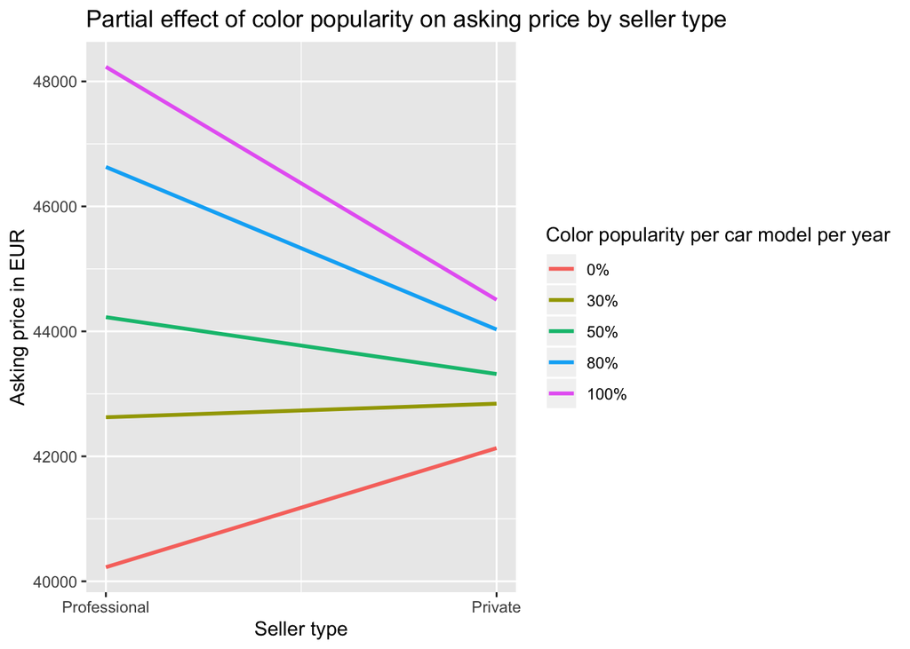

### Partial Effect Interaction Plot: Color*Time

It seems that popular colors only increase a cars value during the first couple of years. This value then diminishes (or reverts) over time. Why it does revert does not make sense to me.

```
## NOTE: sqrt(ageindays)colpopPYPM is not a high-order term in the model
```

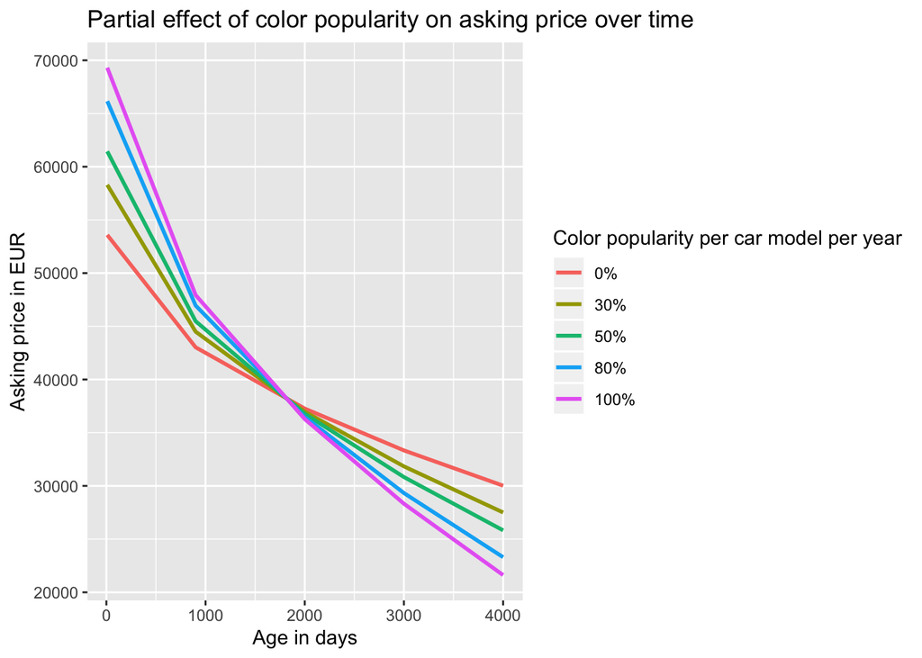

### Partial Effect Interaction Plot: Color x Time x PrivateSeller

This plot does not add a lot. What can be seen is that professional sellers (Plot 0) price better for popular colors initially and then the relationship inverts later and the inversion is less extreme.

```
## NOTE: privatesellercolpopPYPMsqrt(ageindays) is not a high-order term in the model
```

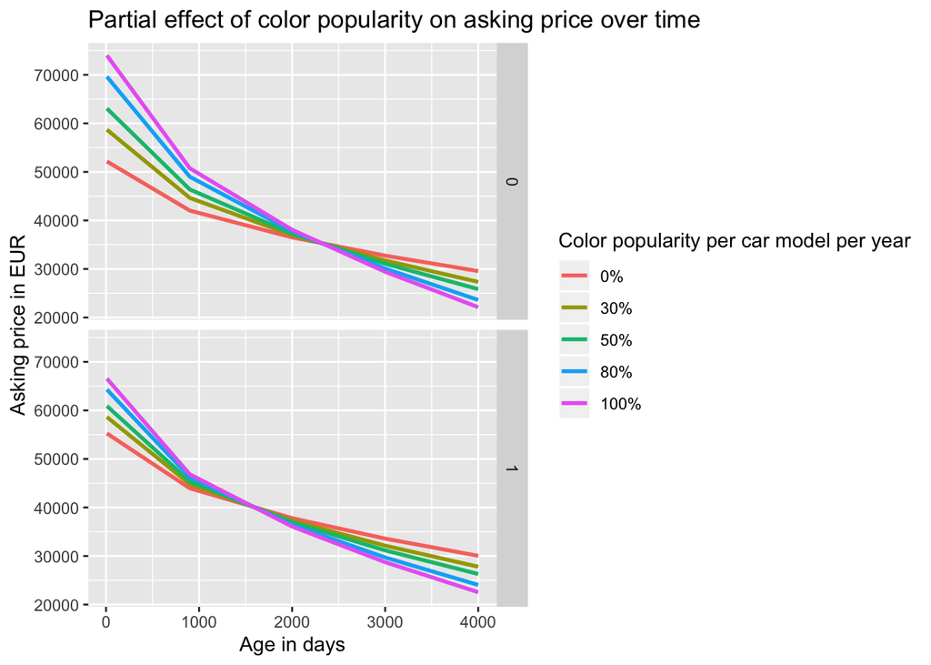

## Looking at color popularity by model

Maybe the year of first registration only unnecessarily restricts the analysis. However, it seems that adding in the year of the registration adds value.

*Dependent variable:*

Price

(1)

(2)

(3)

colpopPM

2,041.286***

4,276.749***

15,650.140***

(458.786)

(565.788)

(689.907)

privateseller

457.364***

1,198.592***

470.013***

(118.759)

(161.809)

(118.522)

sport

1,692.310***

1,677.803***

1,718.148***

(67.368)

(67.394)

(67.240)

individual

-4,114.230***

-4,121.721***

-4,047.258***

(378.323)

(378.275)

(377.572)

Power

96.214***

96.272***

96.297***

(1.190)

(1.190)

(1.188)

sqrt(Mileage)

-35.477***

-35.435***

-35.090***

(0.499)

(0.499)

(0.499)

sqrt(ageindays)

-496.700***

-498.019***

-394.940***

(4.237)

(4.241)

(5.725)

TransmissionHalbautomatik

-1,318.377

-1,284.010

-1,223.421

(1,728.425)

(1,728.206)

(1,724.966)

TransmissionSchaltgetriebe

-488.221***

-490.555***

-512.477***

(83.068)

(83.058)

(82.907)

hud

1,792.056***

1,783.280***

1,776.608***

(120.191)

(120.182)

(119.951)

acc

518.047***

517.401***

558.295***

(151.941)

(151.922)

(151.645)

glasdach

304.572

306.035

289.479

(164.413)

(164.392)

(164.085)

laser

5,513.027***

5,496.243***

5,312.727***

(481.521)

(481.464)

(480.616)

led

-1,362.486***

-1,368.407***

-1,318.302***

(75.910)

(75.905)

(75.777)

leather

29.995

24.561

13.868

(111.179)

(111.168)

(110.958)

navi

-1,742.073***

-1,736.391***

-1,728.970***

(64.368)

(64.365)

(64.240)

standheizung

257.754

272.810

287.270

(257.851)

(257.827)

(257.337)

brandBMW

-4,088.797

-3,999.277

-4,155.346

(7,017.589)

(7,009.719)

(6,974.002)

brandMercedes

10,100.020

9,938.684

10,404.360

(6,787.592)

(6,780.015)

(6,745.463)

colpopPM:privateseller

-3,168.404***

(469.780)

colpopPM:sqrt(ageindays)

-433.459***

(16.437)

Constant

45,465.160***

45,073.730***

41,886.530***

(6,234.486)

(6,230.504)

(6,194.175)

Observations

171,875

171,875

171,875

Log Likelihood

-1,858,369.000

-1,858,339.000

-1,858,018.000

Akaike Inf. Crit.

3,716,788.000

3,716,730.000

3,716,088.000

Bayesian Inf. Crit.

3,717,039.000

3,716,992.000

3,716,350.000

*Note:*

- p<0.05; ** p<0.01; *** p<0.001

### Partial Effect Interaction Plot: Color*Seller Type

It seems that private sellers do not realize the effect of color popularity. They overprice individual, unpopular colors vs. professional sellers and underprice popular colors. Professional sellers seem to have a feeling for “which color works for which model”.

```
## NOTE: privatesellercolpopPM does not appear in the model
```

```
## NOTE: privatesellercolpopPM is not a high-order term in the model
```

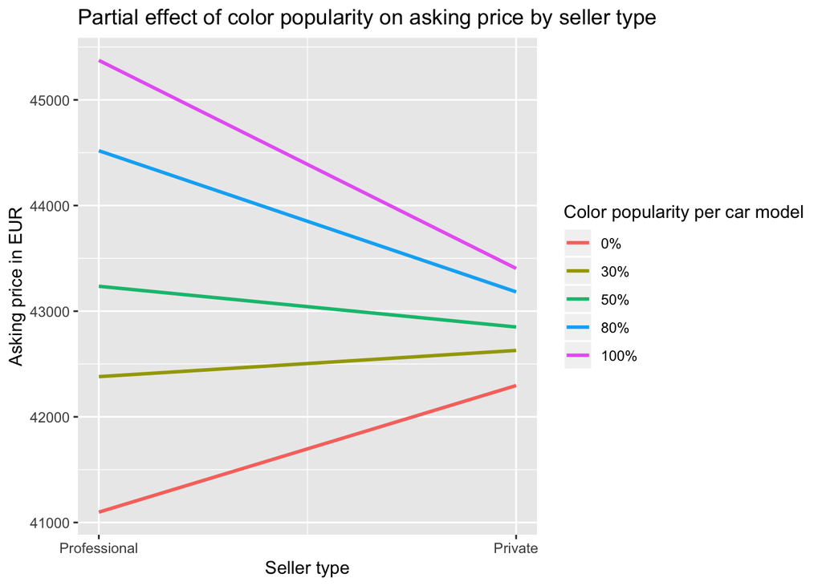

### Partial Effect Interaction Plot: Color*Time

It seems that popular colors only increase a cars value during the first couple of years. This value then diminishes (or reverts) over time. Why it does revert does not make sense to me. Maybe this is a consequence of more private sellers coming in later?

```
## NOTE: sqrt(ageindays)colpopPM is not a high-order term in the model
```

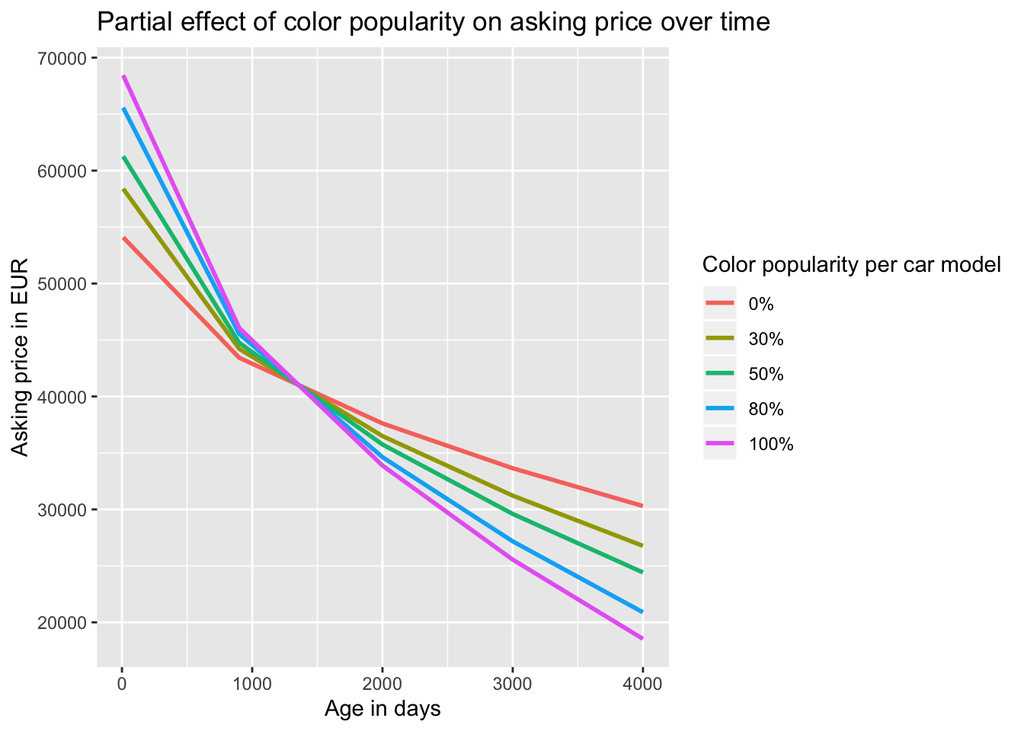

# Color Value Loss

## Looking at overall color popularity

```
## fixed-effect model matrix is rank deficient so dropping 4 columns / coefficients
```

```
## boundary (singular) fit: see ?isSingular
```

*Dependent variable:*

Rem.Value

colpop

-0.045*

(0.021)

privateseller

3.029***

(0.719)

sport

-0.664

(1.580)

Power

0.118***

(0.007)

sqrt(Mileage)

-0.090***

(0.004)

sqrt(ageindays)

-0.981***

(0.035)

TransmissionSchaltgetriebe

12.427***

(0.867)

laser

-7.522

(24.763)

led

0.107

(1.393)

leather

-6.710

(6.289)

navi

29.240***

(0.800)

standheizung

-4.573

(2.892)

brandBMW

-9.729

(14.913)

Constant

98.864***

(11.769)

Observations

11,416

Log Likelihood

-52,851.470

Akaike Inf. Crit.

105,740.900

Bayesian Inf. Crit.

105,880.400

*Note:*

- p<0.05; ** p<0.01; *** p<0.001

## Looking at color popularity by the year of first registration

```
## fixed-effect model matrix is rank deficient so dropping 4 columns / coefficients
```

```
## boundary (singular) fit: see ?isSingular
```

*Dependent variable:*

Rem.Value

colpopPY

-4.454*

(2.071)

privateseller

3.030***

(0.719)

sport

-0.665

(1.580)

Power

0.118***

(0.007)

sqrt(Mileage)

-0.090***

(0.004)

sqrt(ageindays)

-0.980***

(0.035)

TransmissionSchaltgetriebe

12.426***

(0.867)

laser

-7.487

(24.763)

led

0.117

(1.393)

leather

-6.698

(6.289)

navi

29.230***

(0.800)

standheizung

-4.547

(2.892)

brandBMW

-9.752

(14.917)

Constant

98.878***

(11.776)

Observations

11,416

Log Likelihood

-52,846.870

Akaike Inf. Crit.

105,731.700

Bayesian Inf. Crit.

105,871.300

*Note:*

- p<0.05; ** p<0.01; *** p<0.001

## Looking at color popularity by the year of first registration and by model

Color is not significant anymore.

```
## fixed-effect model matrix is rank deficient so dropping 4 columns / coefficients
```

```
## boundary (singular) fit: see ?isSingular
```

```
## fixed-effect model matrix is rank deficient so dropping 4 columns / coefficients
```

```
## boundary (singular) fit: see ?isSingular
```

```
## fixed-effect model matrix is rank deficient so dropping 4 columns / coefficients
```

```
## boundary (singular) fit: see ?isSingular
```

*Dependent variable:*

Rem.Value

(1)

(2)

(3)

colpopPYPM

-2.151

-7.144**

2.983

(1.619)

(2.623)

(4.055)

privateseller

3.035***

1.131

3.045***

(0.719)

(1.066)

(0.719)

sport

-0.695

-0.784

-0.697

(1.580)

(1.580)

(1.580)

Power

0.119***

0.119***

0.119***

(0.007)

(0.007)

(0.007)

sqrt(Mileage)

-0.090***

-0.090***

-0.090***

(0.004)

(0.004)

(0.004)

sqrt(ageindays)

-0.976***

-0.974***

-0.938***

(0.035)

(0.035)

(0.045)

TransmissionSchaltgetriebe

12.374***

12.379***

12.370***

(0.866)

(0.866)

(0.866)

laser

-7.332

-8.406

-9.080

(24.773)

(24.771)

(24.804)

led

0.147

0.204

0.211

(1.393)

(1.393)

(1.394)

leather

-6.634

-6.630

-6.849

(6.290)

(6.289)

(6.292)

navi

29.231***

29.208***

29.272***

(0.800)

(0.798)

(0.802)

standheizung

-4.579

-4.520

-4.527

(2.893)

(2.892)

(2.893)

brandBMW

-9.433

-10.280

-9.627

(14.841)

(14.885)

(14.915)

colpopPYPM:privateseller

8.020*

(3.315)

colpopPYPM:sqrt(ageindays)

-0.156

(0.113)

Constant

98.181***

99.707***

97.105***

(11.680)

(11.749)

(11.781)

Observations

11,416

11,416

11,416

Log Likelihood

-52,848.550

-52,843.510

-52,848.860

Akaike Inf. Crit.

105,735.100

105,727.000

105,737.700

Bayesian Inf. Crit.

105,874.600

105,873.900

105,884.600

*Note:*

- p<0.05; ** p<0.01; *** p<0.001

## Looking at color popularity by model

Again, this is insignificant.

```
## fixed-effect model matrix is rank deficient so dropping 4 columns / coefficients
```

```
## boundary (singular) fit: see ?isSingular
```

```
## fixed-effect model matrix is rank deficient so dropping 4 columns / coefficients
```

```
## boundary (singular) fit: see ?isSingular
```

```
## fixed-effect model matrix is rank deficient so dropping 4 columns / coefficients
```

```
## boundary (singular) fit: see ?isSingular
```

*Dependent variable:*

Rem.Value

(1)

(2)

(3)

colpopPM

-3.811

-9.151**

6.172

(2.014)

(2.938)

(5.410)

privateseller

3.023***

0.853

3.065***

(0.719)

(1.128)

(0.719)

sport

-0.665

-0.731

-0.649

(1.580)

(1.580)

(1.580)

Power

0.119***

0.118***

0.118***

(0.007)

(0.007)

(0.007)

sqrt(Mileage)

-0.090***

-0.090***

-0.089***

(0.004)

(0.004)

(0.004)

sqrt(ageindays)

-0.980***

-0.979***

-0.915***

(0.035)

(0.035)

(0.048)

TransmissionSchaltgetriebe

12.415***

12.423***

12.414***

(0.867)

(0.866)

(0.867)

laser

-7.522

-8.276

-8.372

(24.765)

(24.761)

(24.765)

led

0.104

0.141

0.215

(1.393)

(1.393)

(1.395)

leather

-6.669

-6.624

-6.794

(6.289)

(6.288)

(6.289)

navi

29.236***

29.196***

29.281***

(0.800)

(0.797)

(0.802)

standheizung

-4.593

-4.621

-4.446

(2.892)

(2.892)

(2.893)

brandBMW

-9.465

-9.975

-9.669

(14.927)

(14.863)

(15.017)

colpopPM:privateseller

9.956*

(3.987)

colpopPM:sqrt(ageindays)

-0.304*

(0.153)

Constant

98.691***

100.071***

96.662***

(11.779)

(11.725)

(11.901)

Observations

11,416

11,416

11,416

Log Likelihood

-52,847.420

-52,842.010

-52,846.410

Akaike Inf. Crit.

105,732.800

105,724.000

105,732.800

Bayesian Inf. Crit.

105,872.400

105,870.900

105,879.700

*Note:*

- p<0.05; ** p<0.01; *** p<0.001